# ECON 491 - Applied Machine Learning in Economics Problem Set 8 (50pts) - due date: Friday, April 21

Antony Violaris (aev4)

04/21/2023

# Question 1 (applied)[12p]

Generate a simulated two-class data set with 100 observations and two features in which there is a visible but non-linear separation between the two classes. Show that in this setting, a support vector machine with a polynomial kernel (with degree greater than 1) or a radial kernel will outperform a support vector classifier on the training data. Which technique performs best on the test data? Make plots and report training and test error rates in order to back up your assertions.

# Answer 1

I create a $n=100$ random initial dataset around the parabola $y= 4 x^2 + 7$. Then I seperate the two classes and visualize them to show the non-linearity.

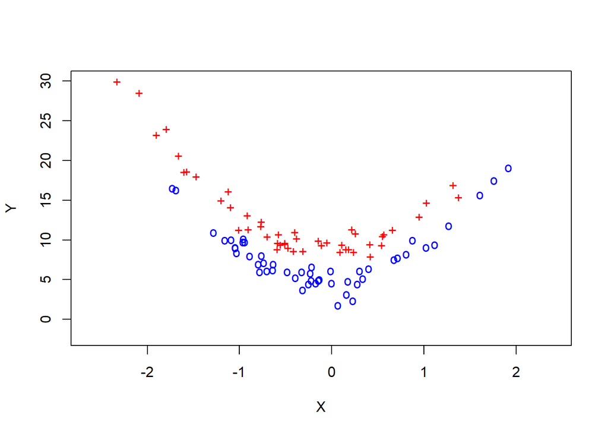

```r
set.seed(1990)
# Generating a dataset with visible non-linear separation.
x <- rnorm(100)
y <- 4 * x^2 + 7 + rnorm(100)
train <- sample(100, 50)
y[train] <- y[train] + 2
y[-train] <- y[-train] - 2
plot(x[train], y[train], pch="+", lwd=4, col="red", ylim=c(-2, 30), xlab="X", ylab="Y")
points(x[-train], y[-train], pch="o", lwd=4, col="blue")
```

```r
# Create train and test dataframes
z <- rep(0, 100)
z[train] <- 1
# Take 25 observations each from train and -train
final.train <- c(sample(train, 25), sample(setdiff(1:100, train), 25))
data.train <- data.frame(x=x[final.train], y=y[final.train], z=as.factor(z[final.train]))
data.test <- data.frame(x=x[-final.train], y=y[-final.train], z=as.factor(z[-final.train]))
```

```r
library(e1071)
```

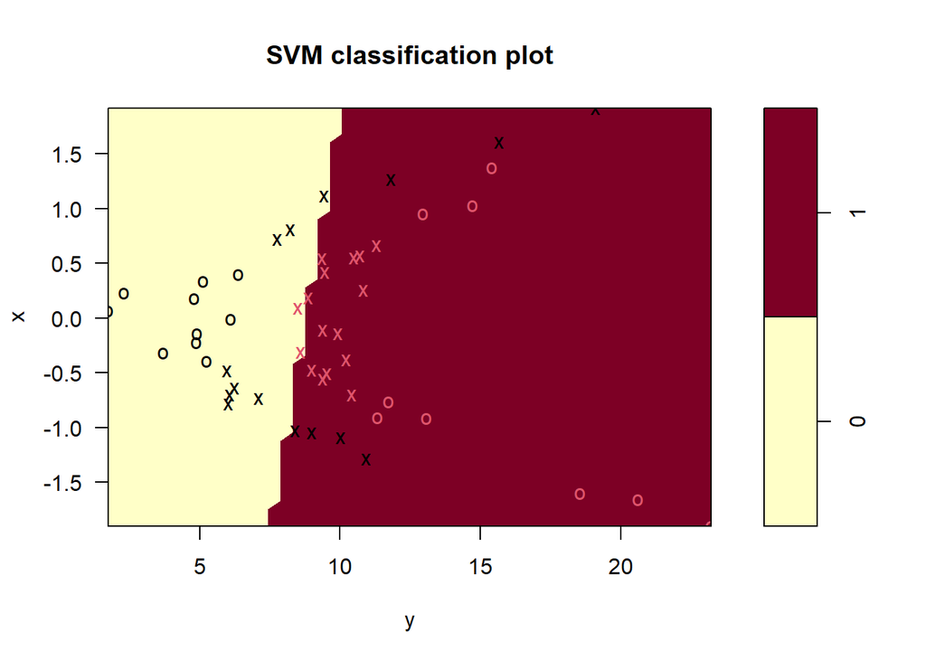

```r
svm.linear = svm(z~., data=data.train, kernel="linear", cost=10)
plot(svm.linear, data.train)
```

```r
table(z[final.train], predict(svm.linear, data.train))
```

```
##
##      0  1
##   0 17  8
##   1  1 24
```

The linear classifier makes 9 classification errors on train data.

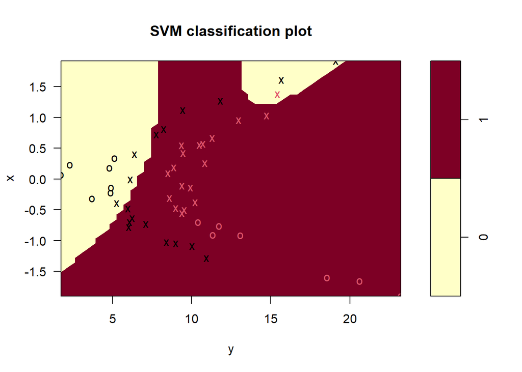

```r
svm.poly = svm(z~., data=data.train, kernel="polynomial", cost=10, degree=3)
plot(svm.poly, data.train)
```

```r
table(z[final.train], predict(svm.poly, data.train))
```

```
##
##      0  1
##   0 12 13
##   1  1 24
```

The default polynomial kernel with degree 3 makes 14 errors on train data.

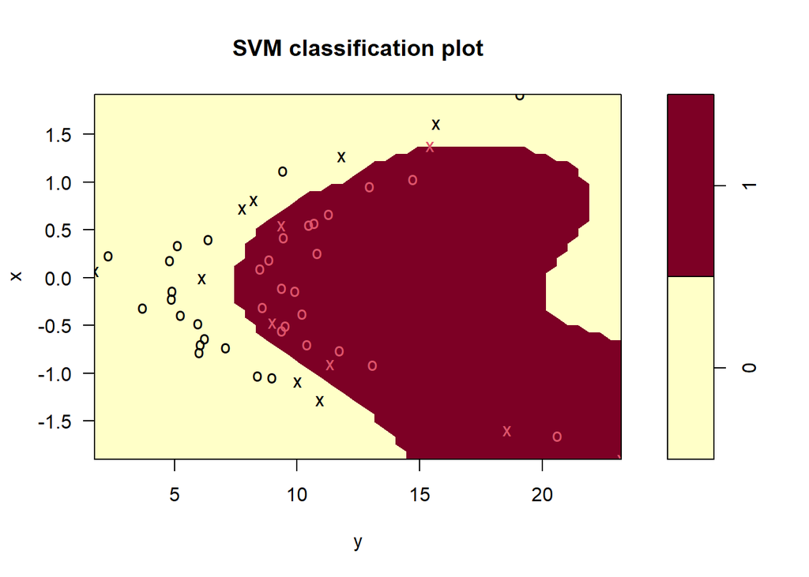

```r
svm.radial = svm(z~., data=data.train, kernel="radial", gamma=1, cost=10)
plot(svm.radial, data.train)
```

```r
table(z[final.train], predict(svm.radial, data.train))
```

```
##
##      0  1
##   0 25  0
##   1  0 25
```

The SVM classifier with radial kernel perfectly classifies train data. The performance in the test data can be shown in the following graphs.

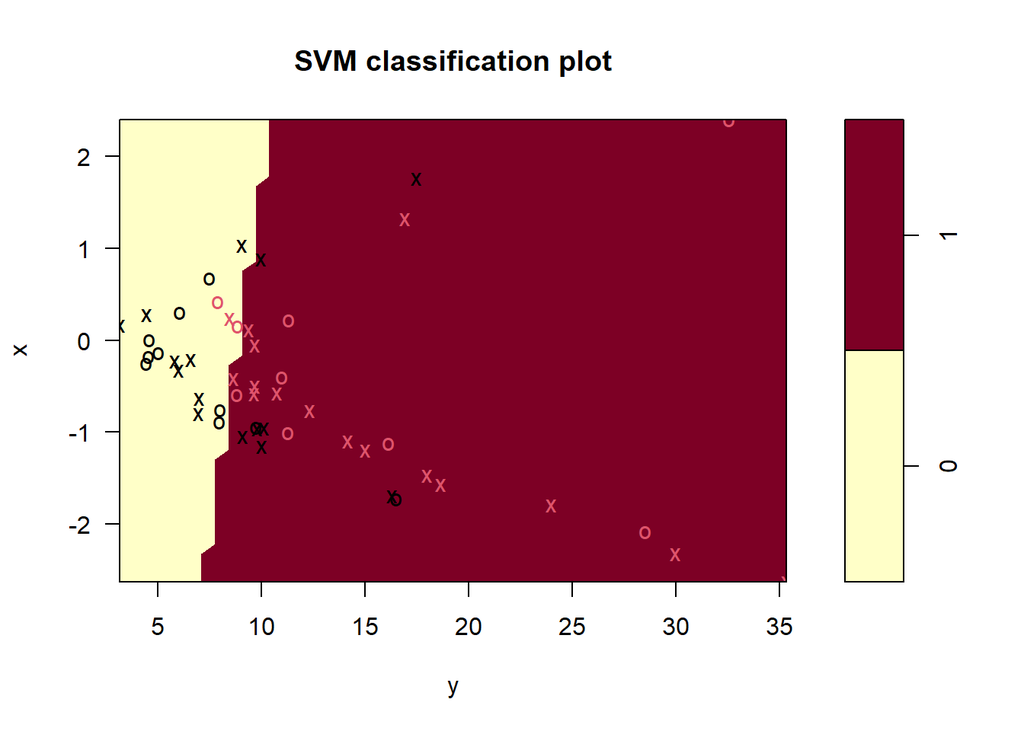

```r
plot(svm.linear, data.test)
```

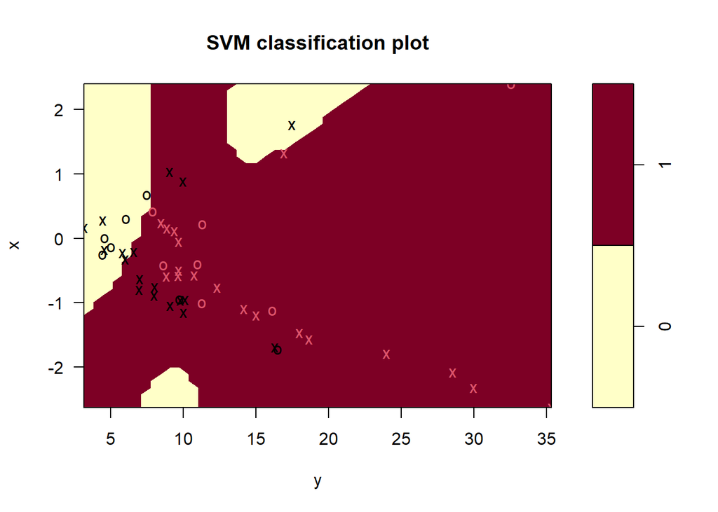

```r
plot(svm.poly, data.test)
```

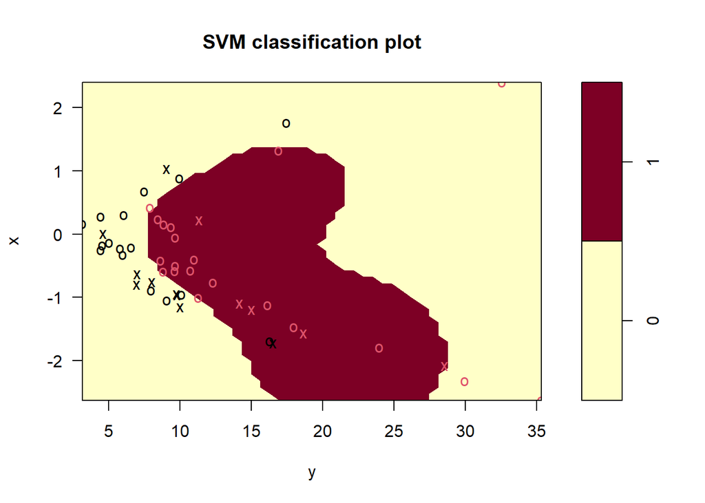

```r
plot(svm.radial, data.test)
```

# Question 2 (applied)[18p (=2x9)]

We have seen that we can fit an SVM with a non-linear kernel in order to perform classification using a non-linear decision boundary. We will now see that we can also obtain a non-linear decision boundary by performing logistic regression using non-linear transformations of the features.

1. Generate a data set with $n=500$ and $p=2$, such that the observations belong to two classes with a quadratic decision boundary between them. For instance, you can do this as follows:

```r
x1 <- runif (500) - 0.5
x2 <- runif (500) - 0.5
y <- 1 * (x1^2 - x2^2 > 0)
```

2. Plot the observations, colored according to their class labels. Your plot should display $X_1$ on the $x$-axis, and $X_2$ on the $y$-axis.
3. Fit a logistic regression model to the data, using $X_1$ and $X_2$ as predictors.
4. Apply this model to the *training data* in order to obtain a predicted class label for each training observation. Plot the observations, colored according to the *predicted class* labels. The decision boundary should be linear.
5. Now fit a logistic regression model to the data using non-linear functions of $X_1$ and $X_2$ as predictors (e.g. $X^2_1$, $X_1 \times X_2$, log($X_2$), and so forth).
6. Apply this model to the *training data* in order to obtain a predicted class label for each training observation. Plot the observations, colored according to the *predicted class* labels. The decision boundary should be obviously non-linear. If it is not, then repeat (a)-(e) until you come up with an example in which the predicted class labels are obviously non-linear.
7. Fit a support vector classifier to the data with $X_1$ and $X_2$ as predictors. Obtain a class prediction for each training observation. Plot the observations, colored according to the *predicted class labels*.
8. Fit a SVM using a non-linear kernel to the data. Obtain a class prediction for each training observation. Plot the observations, colored according to the *predicted class labels*.
9. Comment on your results.

# Answer 2

**b.**

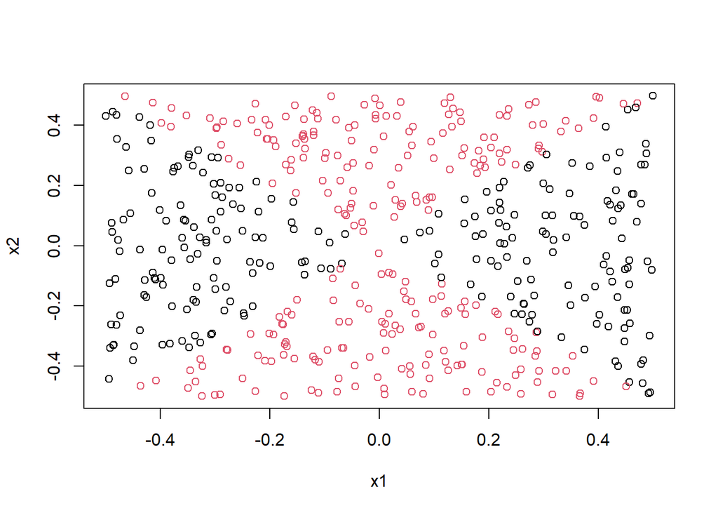

```r
df <- data.frame(x1=x1, x2=x2, y=as.factor(y))
plot(x1, x2, col = (2 - y))
```

**c.**

```r
# Logistic Regression
glm.fit <- glm(y~x1+x2, data=df, family = 'binomial')
```

**d.**

```r
# Predictions
glm.probs <- predict(glm.fit, newdata=df, type = 'response')
glm.preds <- rep(0,500)
glm.preds[glm.probs>0.50] <- 1
table(preds=glm.preds, truth=df$y)
```

```
##      truth
## preds   0   1
##     0 257 228
##     1   8   7
```

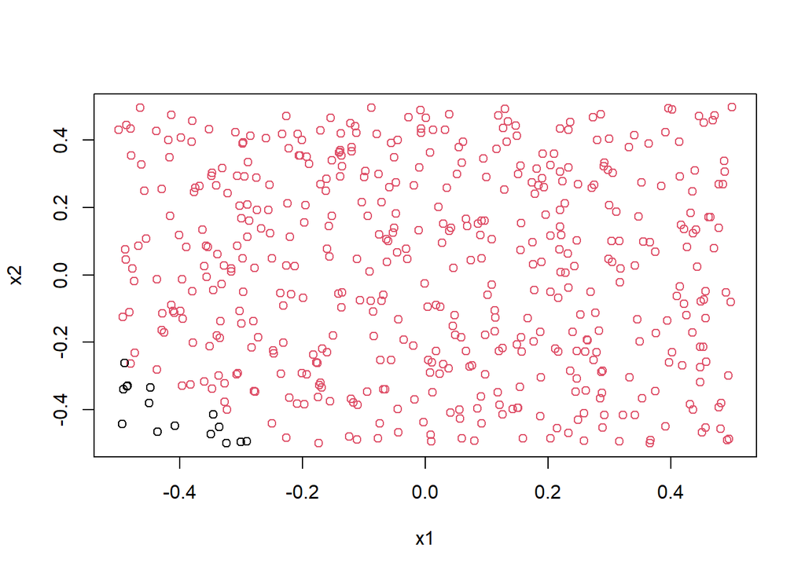

```r
# Plot using predicted class labels for observations
plot(x1,x2,col=(2-glm.preds))
```

**e.**

```r
# Logistic regression using non-linear predictors
glm.fit2 <- glm(y~I(x1^2)+I(x2^2), data = df, family = 'binomial')
```

**f.**

```r
# Predictions
glm.probs2 <- predict(glm.fit2, newdata = df, type = 'response')
glm.preds2 <- rep(0,500)
glm.preds2[glm.probs2>0.5] <- 1
table(preds=glm.preds2, truth=df$y)
```

```
##      truth
## preds   0   1
##     0 265   0
##     1   0 235
```

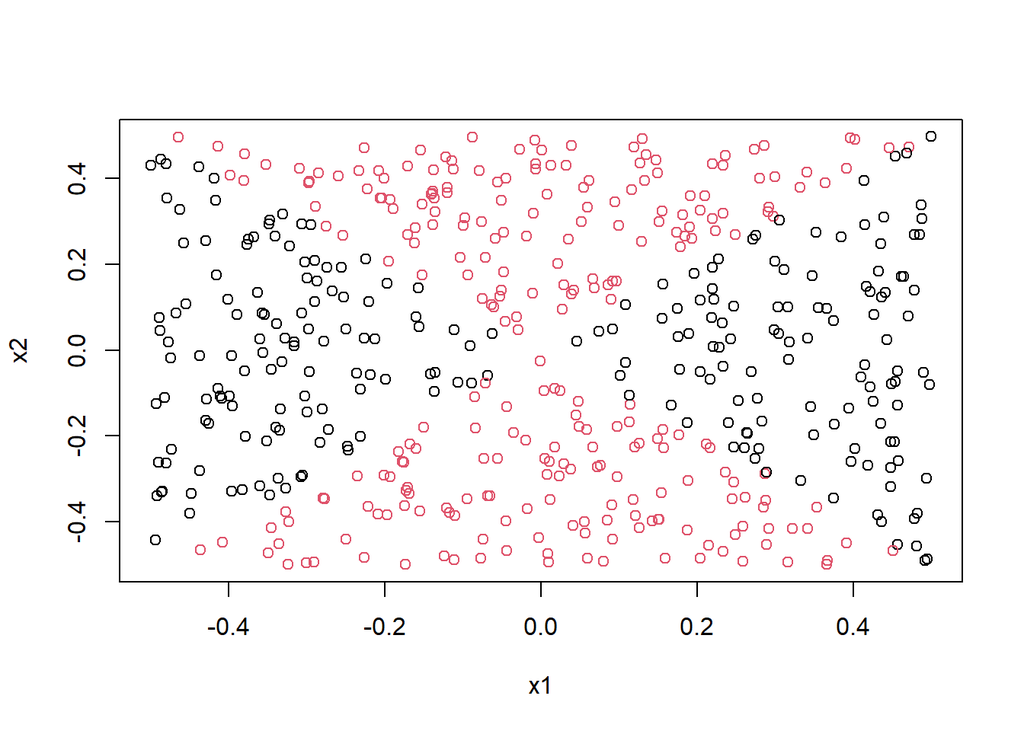

```r
plot(x1,x2,col=2-glm.preds2)
```

**g.**

```r
# Support Vector Classifier
tune.out <- tune(svm,y~.,data = df,kernel='linear', ranges=list(cost=c(0.001,0.01,0.1,1,5,10,100)))
best.mod <- tune.out$best.model
# Predictions
ypred <- predict(best.mod, newdata=df, type='response')
table(predict=ypred, truth=df$y)
```

```
##        truth
## predict   0   1
##       0 265 235
##       1   0   0
```

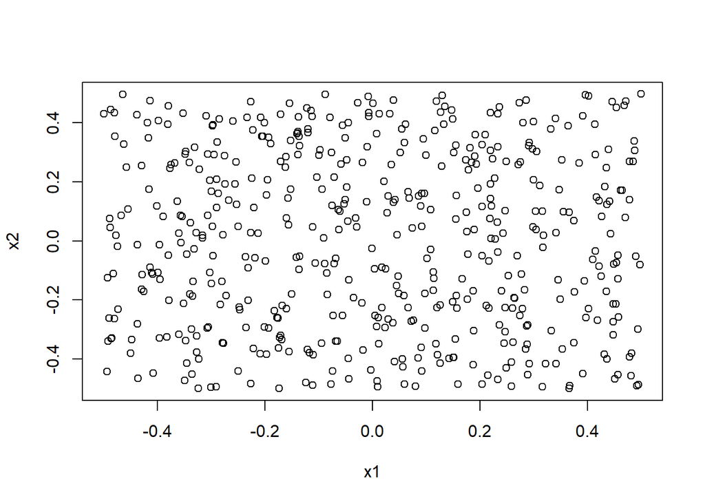

```r
plot(x1,x2,col=ypred)
```

**h.**

```r
# SVM with a non-linear kernel
tune.out2 <- tune(svm, y~., data=df, kernel='radial', ranges=list(cost=c(0.1,1,10,100,1000), gamma=c(0.5,1,2,3,4)))
best.mod2 <- tune.out2$best.model
#Predictions
ypred2 <- predict(best.mod2, newdata=df, type='response')
table(predict=ypred2, truth=df$y)
```

```
##        truth
## predict   0   1
##       0 264   0
##       1   1 235
```

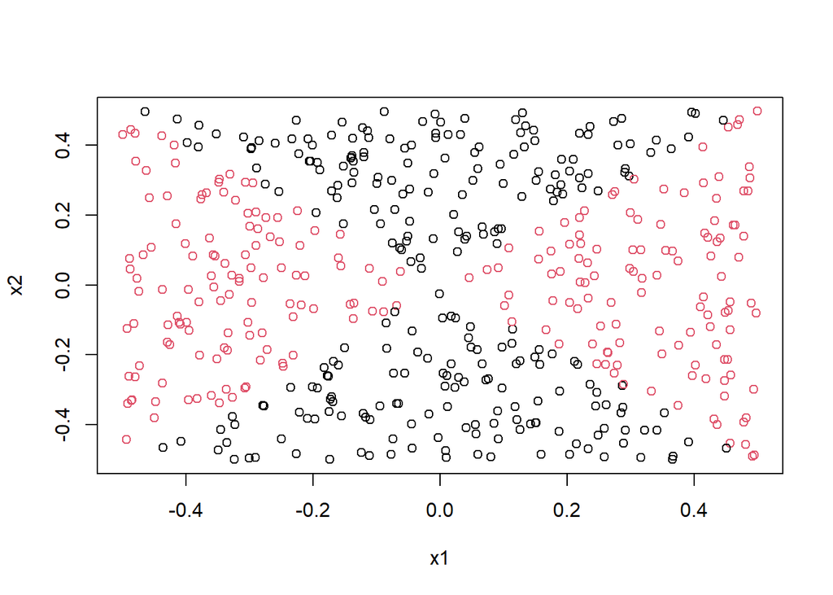

```r
plot(x1,x2,col=ypred2)
```

# Question 3 (applied)[20p (=2.5x8)]

This problem involves the `OJ` data set which is part of the `ISLR2` package.

1. Create a training set containing a random sample of 800 observations, and a test set containing the remaining observations.
2. Fit a support vector classifier to the training data using `cost = 0.01`, with `Purchase` as the response and the other variables as predictors. Use the `summary()` function to produce summary statistics, and describe the results obtained.
3. What are the training and test error rates?
4. Use the `tune()` function to select an optimal cost. Consider values in the range `0.01` to `10`.
5. Compute the training and test error rates using this new value for `cost`.
6. Repeat parts (b) through (e) using a support vector machine with a radial kernel. Use the default value for `gamma`.
7. Repeat parts (b) through (e) using a support vector machine with a polynomial kernel. Set `degree = 2`.
8. Overall, which approach seems to give the best results on this data.

# Answer 3

**a.**

```r
library(ISLR2)
attach(OJ)
```

```r
# Training and test sets.
train <- sample(dim(OJ)[1], 800)
OJ.train <- OJ[train, ]
OJ.test <- OJ[-train, ]
```

**b.**

```r
# Fit a support vector classifier to the training data
svm.fit <- svm(Purchase~., data = OJ.train, kernel = "linear", cost=0.01)
summary(svm.fit)
```

```
##
## Call:
## svm(formula = Purchase ~ ., data = OJ.train, kernel = "linear", cost = 0.01)
##
##
## Parameters:
##    SVM-Type:  C-classification
##  SVM-Kernel:  linear
##        cost:  0.01
##
## Number of Support Vectors:  432
##
##  ( 217 215 )
##
##
## Number of Classes:  2
##
## Levels:
##  CH MM
```

**c.**

```r
# Predictions on training sample
svm.pred.train <- predict(svm.fit, OJ.train)
table(predict=svm.pred.train, truth=OJ.train$Purchase)
```

```
##        truth
## predict  CH  MM
##      CH 435  76
##      MM  57 232
```

```r
training.error <- (76+57)/800
training.error
```

```
## [1] 0.16625
```

```r
# Predictions on test sample
svm.pred.test <- predict(svm.fit, OJ.test)
table(predict=svm.pred.test, truth=OJ.test$Purchase)
```

```
##        truth
## predict  CH  MM
##      CH 133  23
##      MM  28  86
```

```r
test.error <- (23+28)/270
test.error
```

```
## [1] 0.1888889
```

**d.**

```r
# Using cross validation to select optimal cost
tune.out <- tune(svm, Purchase~., data = OJ.train, kernel = "linear",
ranges=list(cost=c(0.01,0.1,0.5,1,10)))
```

**e.**

```r
# Training error
svm.pred.train <- predict(tune.out$best.model, OJ.train)
table(predict=svm.pred.train, truth=OJ.train$Purchase)
```

```
##        truth
## predict  CH  MM
##      CH 432  65
##      MM  60 243
```

```r
training.error <- (65+60)/800
training.error
```

```
## [1] 0.15625
```

```r
# Test error
svm.pred.test <- predict(tune.out$best.model, OJ.test)
table(predict=svm.pred.test, truth=OJ.test$Purchase)
```

```
##        truth
## predict  CH  MM
##      CH 133  23
##      MM  28  86
```

```r
test.error <- (23+28)/270
test.error
```

```
## [1] 0.1888889
```

**f.**

```r
tune.out <- tune(svm, Purchase~., data = OJ.train, kernel = "radial",
ranges=list(cost=c(0.01,0.1,0.5,1,10)))
# Training error
svm.pred.train <- predict(tune.out$best.model, OJ.train)
table(predict=svm.pred.train, truth=OJ.train$Purchase)
```

```
##        truth
## predict  CH  MM
##      CH 445  80
##      MM  47 228
```

```r
training.error <- (80+47)/800
training.error
```

```
## [1] 0.15875
```

```r
# Test error
svm.pred.test <- predict(tune.out$best.model, OJ.test)
table(predict=svm.pred.test, truth=OJ.test$Purchase)
```

```
##        truth
## predict  CH  MM
##      CH 143  23
##      MM  18  86
```

```r
test.error <- (23+18)/270
test.error
```

```
## [1] 0.1518519
```

**g.**

```r
tune.out <- tune(svm, Purchase~., data = OJ.train, kernel = "polynomial",
ranges=list(cost=c(0.01,0.1,0.5,1,10)), degree=2)
# Training error
svm.pred.train <- predict(tune.out$best.model, OJ.train)
table(predict=svm.pred.train, truth=OJ.train$Purchase)
```

```
##        truth
## predict  CH  MM
##      CH 448  79
##      MM  44 229
```

```r
training.error <- (79+44)/800
training.error
```

```
## [1] 0.15375
```

```r
# Test error
svm.pred.test <- predict(tune.out$best.model, OJ.test)
table(predict=svm.pred.test, truth=OJ.test$Purchase)
```

```
##        truth
## predict  CH  MM
##      CH 147  28
##      MM  14  81
```

```r
test.error <- (28+14)/270
test.error
```

```
## [1] 0.1555556
```

**h.** The lowest test error is obtained from the SVM with radial kernel, but the SVM with a polynomial kernel produces similar results.